# hw4gizem

gizemkurtbay

December 19, 2018

```r
#install.packages("rpart.plot")
#install.packages("gbm")
library(rpart.plot)
library(rpart)
library(glmnet)
require(rpart.plot)
```

Four datasets are selected according to the given requirements.

In the first dataset there are more than 50 variables (fetures) It has 54 features.This is a regression problem. The data is not all numerical. There are categorical and ordinal variables. The data is about Facebook Comment Volume. Number of training samples are much more than 200. It is trying to estimate the data o 54th feature in the dataset.

```r
#data  1 is prepared
TrainData <- read.csv(file="C:/Users/Gizem/Desktop/hw4gz/Features_Variant_1.csv", header=FALSE, sep=",")
TestData = read.csv(file="C:/Users/Gizem/Desktop/dataminig1/Dataset/Testing/TestSet/Test_Case_1.csv", header=FALSE, sep=",")
```

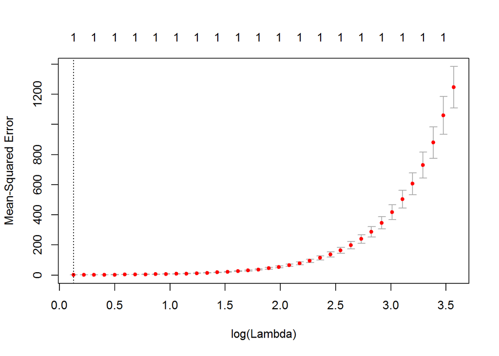

```r
library(glmnet)
astrain = as.matrix (TrainData)
astest = as.matrix (TestData)
cross_validation_data1 = cv.glmnet(astrain,as.matrix(TrainData$V54) ,family="gaussian", alpha=1)
plot(cross_validation_data1)
```

```r
fitted1data <- glmnet(astrain,as.matrix(TrainData$V54),
                      family="gaussian", alpha=1,lambda=cross_validation_data1$lambda.min)
summary(fitted1data)
```

```
##           Length Class     Mode
## a0         1     -none-    numeric
## beta      54     dgCMatrix S4
## df         1     -none-    numeric
## dim        2     -none-    numeric
## lambda     1     -none-    numeric
## dev.ratio  1     -none-    numeric
## nulldev    1     -none-    numeric
## npasses    1     -none-    numeric
## jerr       1     -none-    numeric
## offset     1     -none-    logical
## call       6     -none-    call
## nobs       1     -none-    numeric
```

```r
#Predictions are coded for train data
predict_1st_data <- predict(fitted1data, astrain)
results_1st <- cbind(TrainData$V54, data.frame(predict_1st_data))
error_1st=sum((results_1st[,2] - mean(results_1st[,2]))^2) / sum((results_1st[,1] - mean(results_1st[,1]))^2)

#coeff. of determination for train data of 1st dataset is found as;
print(error_1st)
```

```
## [1] 0.9370382
```

```r
#Predictions are coded for test data

predict_1st_data <- predict(fitted1data, astest)
results_1st <- cbind(TestData$V54, data.frame(predict_1st_data))
error_1st= sum((results_1st[,1] - mean(results_1st[,1]))^2) / sum((results_1st[,2] - mean(results_1st[,2]))^2)
#coeff. of determination for test data of 1st dataset is found as;
print(error_1st)
```

```
## [1] 1.067192
```

Decision Tree for 1st Dataset

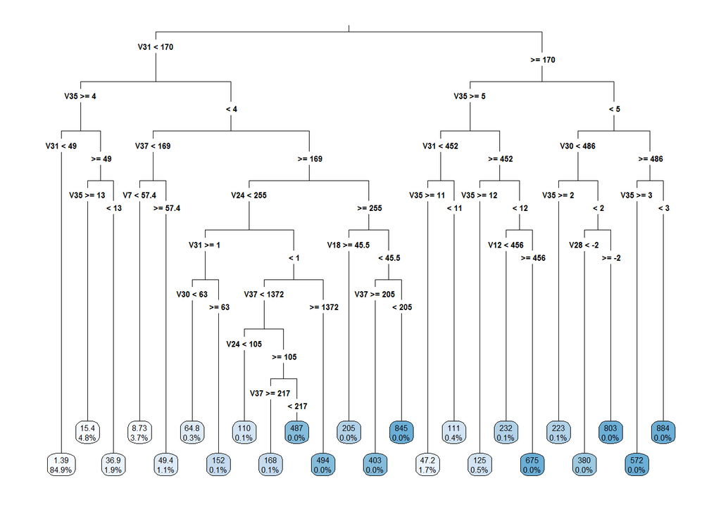

```
## [1] 5.272086
## [1] 29.40066
```

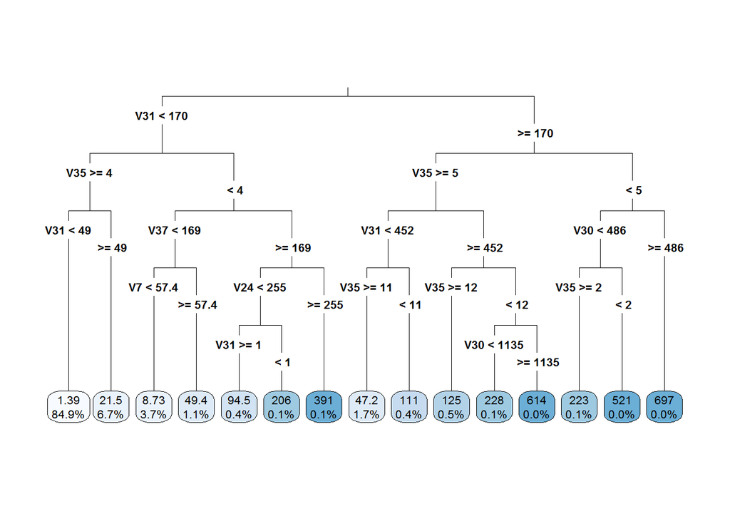

```
## [1] 5.531372
## [1] 19.13949
```

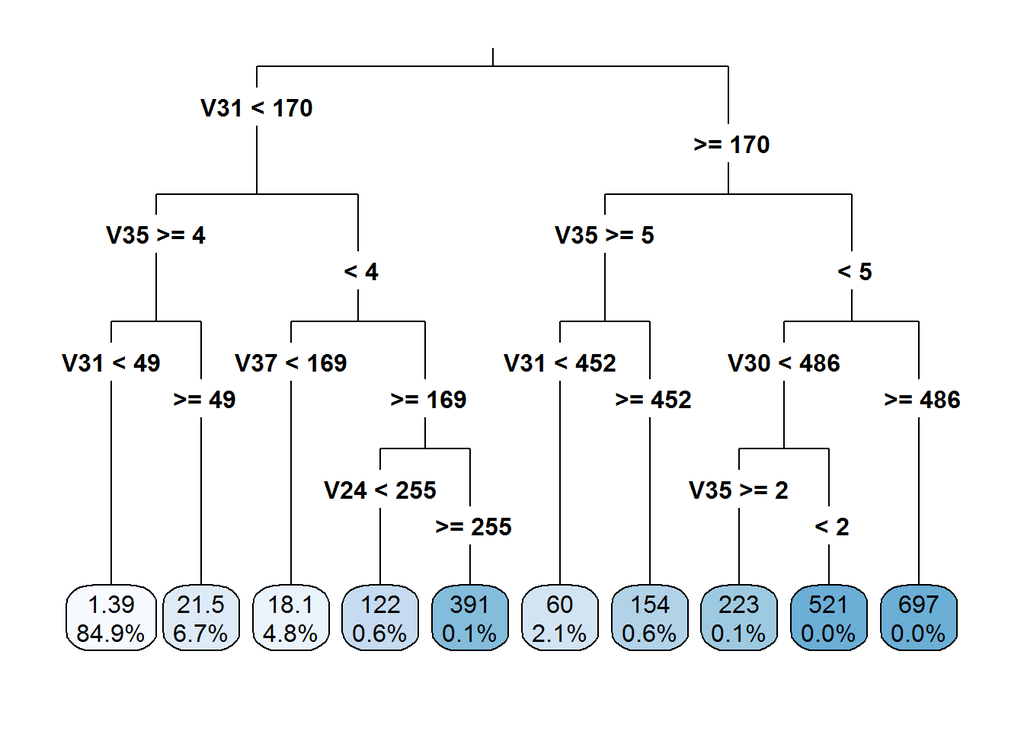

```
## [1] 5.986675
## [1] 24.5947
```

```r
# Decision Tree
require(rpart.plot)
for (i in 1:3){
  set.seed(124)
  desiciontree1 <- rpart(V54 ~ V1 + V2 + V3 + V4 + V5 + V6 + V7 + V8 + V9 + V10 + V11 + V12 + V13+ V14 + V15 + V16 + V17 + V18 + V19 + V20 + V21 + V22 + V23+ V24 + V25 +
                           V26 + V27 + V28 + V29 + V30 + V31 + V32 + V33+ V34 + V35 + V36 + V37 + V38 + V39 + V40 + V41 + V42 + V43+ V44 + V45 + V46 + V47 + V48 + V49 + V50
                         + V51 + V52 + V53, data=TrainData, control=rpart.control(minbucket = 2+i,cp=0.005*i),method = "anova")

  rpart.plot(desiciontree1,type = 3,digits = 3,fallen.leaves = TRUE)
  #Predictions
  pred1train<-predict(desiciontree1,TrainData)
  #Mean Absolute Error for train data

  MeanAbsError<-function(actual,predicted){mean(abs(actual - predicted))
  }
  pred1test<-predict(desiciontree1,TestData)

  #mean absolute error for train data is found as
  print(MeanAbsError(TrainData$V54,pred1train))
  #mean absolute error for test data is found as
  print(MeanAbsError(TestData$V54,pred1test))
}
```

Results are the mean absolute errors for train and test datas for i=1,2,3respectively.

```r
print(desiciontree1)
```

```
## n= 40949
##
## node), split, n, deviance, yval
##       * denotes terminal node
##
##  1) root 40949 51588870.0   7.322889
##    2) V31< 169.5 39746 20193130.0   4.548558
##      4) V35>=3.5 37502  3667873.0   2.862381
##        8) V31< 48.5 34749   489087.0   1.387695 *
##        9) V31>=48.5 2753  2149373.0  21.476210 *
##      5) V35< 3.5 2244 14636700.0  32.728160
##       10) V37< 168.5 1985  3005807.0  18.059450 *
##       11) V37>=168.5 259  7930325.0 145.150600
##         22) V24< 255.4953 237  4278301.0 122.312200 *
##         23) V24>=255.4953 22  2196717.0 391.181800 *
##    3) V31>=169.5 1203 20982460.0  98.984210
##      6) V35>=4.5 1120  9287134.0  80.253570
##       12) V31< 451.5 880  3720055.0  60.046590 *
##       13) V31>=451.5 240  3890236.0 154.345800 *
##      7) V35< 4.5 83  6000102.0 351.734900
##       14) V30< 486 68  3069424.0 275.588200
##         28) V35>=1.5 56  1248197.0 223.053600 *
##         29) V35< 1.5 12   945422.2 520.750000 *
##       15) V30>=486 15   748962.9 696.933300 *
```

```r
print("cp values for error rates")
```

```
## [1] "cp values for error rates"
```

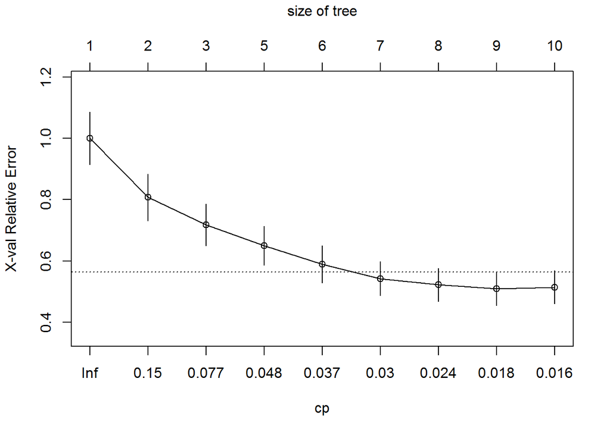

```r
plotcp(desiciontree1)
```

Support Vector Machines for 1st Dataset

```r
# Support Vector Machines

library(e1071)
set.seed(124)
#the original train data had 40949 observations with 54 variables which required a very long run time in r for support vector machine code
#Therefore a short version of train data is used for this svm method for time concerns. This short version contains 200 observations with 54 variables.

ShortofTrainData <- read.csv(file="C:/Users/Gizem/Desktop/hw4gz/shortof_Features_Variant_1.csv", header=FALSE, sep=",")
```

```r
shortfittedsvm<-svm(V54 ~ V1 + V3 + V4 + V5 + V6 + V7 + V8 + V9 + V10 + V11 + V12 + V13+ V14+ V16 + V17 + V18 + V19 + V20 + V21 + V22 + V23+ V24 + V25 +
                      V26 + V27 + V28 + V29 + V30 + V31 + V32 + V33+ V34 + V35 + V36 + V37 + V40 + V41 + V42 + V43+ V44 + V45 + V46 + V47 + V48 + V49 + V50
                    + V51 + V52 + V53,data = ShortofTrainData,kernel="radial")
print(shortfittedsvm)
```

```
##
## Call:
## svm(formula = V54 ~ V1 + V3 + V4 + V5 + V6 + V7 + V8 + V9 + V10 +
##     V11 + V12 + V13 + V14 + V16 + V17 + V18 + V19 + V20 + V21 +
##     V22 + V23 + V24 + V25 + V26 + V27 + V28 + V29 + V30 + V31 +
##     V32 + V33 + V34 + V35 + V36 + V37 + V40 + V41 + V42 + V43 +
##     V44 + V45 + V46 + V47 + V48 + V49 + V50 + V51 + V52 + V53,
##     data = ShortofTrainData, kernel = "radial")
##
##
## Parameters:
##    SVM-Type:  eps-regression
##  SVM-Kernel:  radial
##        cost:  1
##       gamma:  0.02040816
##     epsilon:  0.1
##
##
## Number of Support Vectors:  61
```

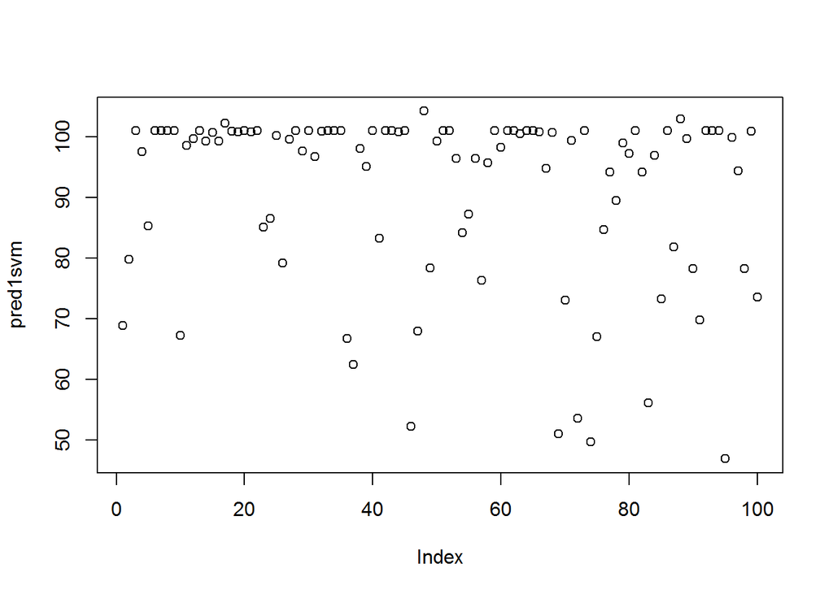

```r
pred1svm<-predict(shortfittedsvm,TestData)
plot(pred1svm)
```

```r
resultsvm<-cbind(TestData$V54, data.frame(pred1svm))
error1svm=sum((resultsvm[,2] - mean(resultsvm[,2]))^2) / sum((resultsvm[,1] - mean(resultsvm[,1]))^2)
#"coefficient of determination is found as
print(error1svm)
```

```
## [1] 0.03021478
```

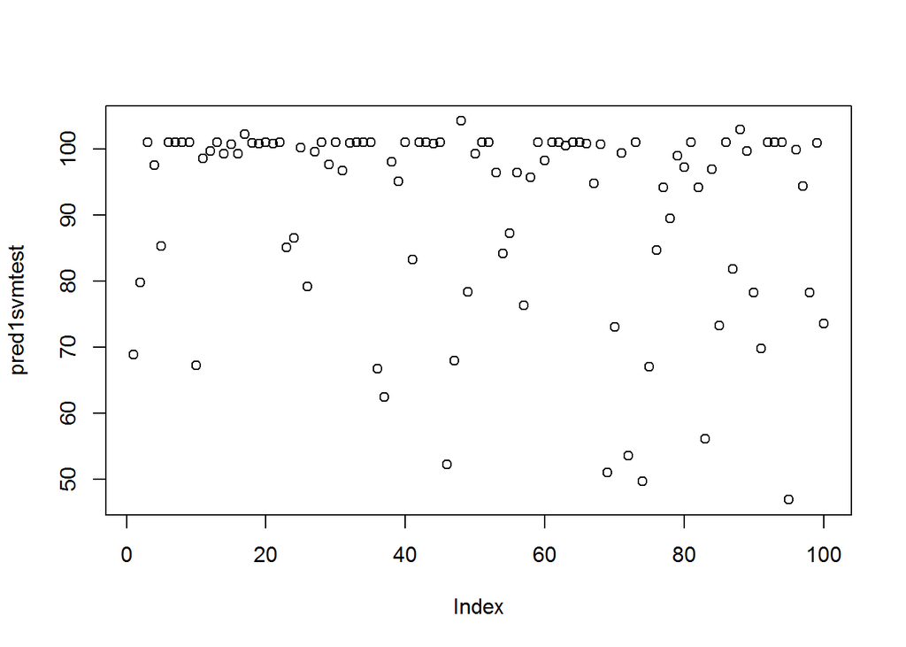

```r
pred1svmtest<-predict(shortfittedsvm,TestData)
plot(pred1svmtest)
```

```r
result1svmtest<-cbind(TestData$V54, data.frame(pred1svmtest))
error1scmtest=sum((result1svmtest[,2] - mean(result1svmtest[,2]))^2) / sum((result1svmtest[,1] - mean(result1svmtest[,1]))^2)
#coefficient of determination can be found as
print(error1scmtest)
```

```
## [1] 0.03021478
```

Stochastic Gradient Boosting for 1st Dataset

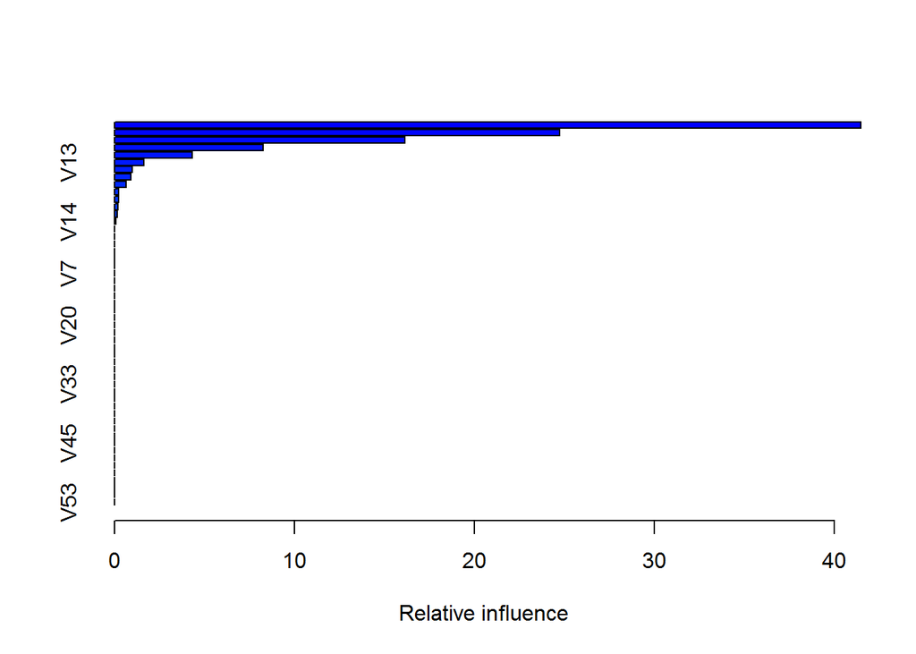

```
##     var     rel.inf
## V31 V31 41.46733952
## V34 V34 24.74023784
## V35 V35 16.14060751
## V37 V37  8.27338150
## V12 V12  4.32558681
## V13 V13  1.61854963
## V17 V17  0.98316004
## V9   V9  0.91734213
## V27 V27  0.63519097
## V23 V23  0.24409050
## V24 V24  0.22697618
## V22 V22  0.20303078
## V16 V16  0.13751574
## V14 V14  0.08699085
## V1   V1  0.00000000
## V2   V2  0.00000000
## V3   V3  0.00000000
## V4   V4  0.00000000
## V5   V5  0.00000000
## V6   V6  0.00000000
## V7   V7  0.00000000
## V8   V8  0.00000000
## V10 V10  0.00000000
## V11 V11  0.00000000
## V15 V15  0.00000000
## V18 V18  0.00000000
## V19 V19  0.00000000
## V20 V20  0.00000000
## V21 V21  0.00000000
## V25 V25  0.00000000
## V26 V26  0.00000000
## V28 V28  0.00000000
## V29 V29  0.00000000
## V30 V30  0.00000000
## V32 V32  0.00000000
## V33 V33  0.00000000
## V36 V36  0.00000000
## V39 V39  0.00000000
## V40 V40  0.00000000
## V41 V41  0.00000000
## V42 V42  0.00000000
## V43 V43  0.00000000
## V44 V44  0.00000000
## V45 V45  0.00000000
## V46 V46  0.00000000
## V47 V47  0.00000000
## V48 V48  0.00000000
## V49 V49  0.00000000
## V50 V50  0.00000000
## V51 V51  0.00000000
## V52 V52  0.00000000
## V53 V53  0.00000000
```

```r
#Stochastic Gradient Boosting
library(caret)
require(gbm)
set.seed(124)

boosting1<-gbm(V54 ~ V1 + V2 + V3 + V4 + V5 + V6 + V7 + V8 + V9 + V10 + V11 + V12 + V13+ V14 + V15 + V16 + V17 + V18 + V19 + V20 + V21 + V22 + V23+ V24 + V25 +
                 V26 + V27 + V28 + V29 + V30 + V31 + V32 + V33+ V34 + V35 + V36 + V37  + V39 + V40 + V41 + V42 + V43+ V44 + V45 + V46 + V47 + V48 + V49 + V50
               + V51 + V52 + V53,data = TrainData,distribution="gaussian",cv.folds = 3)
summary(boosting1)
```

```r
preddata1gbm<-as.data.frame(predict(boosting1,n.trees = 100))
resultgbm<-cbind(TrainData$V54, preddata1gbm)
```

```r
errortrain=sum((resultgbm[,2] - mean(resultgbm[,2]))^2) / sum((resultgbm[,1] - mean(resultgbm[,1]))^2)
#coefficient of determination is found as for train data
print(errortrain)
```

```
## [1] 0.3780504
```

```r
preddata1gbm<-as.data.frame(predict(boosting1,TestData, n.trees = 100))
resultgbm<-cbind(TestData$V54, preddata1gbm)
```

```r
errortest=sum((resultgbm[,2] - mean(resultgbm[,2]))^2) / sum((resultgbm[,1] - mean(resultgbm[,1]))^2)
#coefficient of determination is found as for test data
print(errortest)
```

```
## [1] 0.3958367
```

2nd Dataset

Dataset is prepared. There was no test data, therefore it is created by using the coding below.

```r
Datadiabet <- read.csv(file="C:/Users/Gizem/Desktop/dataset_diabetes/diabetic_data.csv", header=TRUE, sep=",")
#Datadiabet <- read.csv(file="C:/Users/Gizem/Desktop/dataset_diabetes/na_deleted_diabetic_data.csv", header=TRUE, sep=",")

## 75% of the sample size
smp_size <- floor(0.75 * nrow(Datadiabet))

## set the seed to make your partition reproducible
set.seed(123)
train_ind <- sample(seq_len(nrow(Datadiabet)), size = smp_size)

traindiabet <- Datadiabet[train_ind, ]
testdiabet <- Datadiabet[-train_ind, ]
```

[figure not shown]

```
## [1] 1.838698
## [1] 1.873715
```

[figure not shown]

```
## [1] 1.894415
## [1] 1.911728
```

[figure not shown]

```
## [1] 1.924688
## [1] 1.946906
```

```r
# Decision Tree
require(rpart.plot)
for (i in 1:3){
  set.seed(124)
  desiciontree2 <- rpart(time_in_hospital~., data=traindiabet, control=rpart.control(minbucket = 2+i,cp=0.005*i),method = "anova")

  rpart.plot(desiciontree2,type = 3,digits = 3,fallen.leaves = TRUE)
  #Predictions
  pred2train<-predict(desiciontree2,traindiabet)
  #Mean Absolute Error for train data

  MeanAbsError<-function(actual,predicted){mean(abs(actual - predicted))
  }
  pred2test<-predict(desiciontree2,testdiabet)

  #mean absolute error for train data is found as
  print(MeanAbsError(traindiabet$time_in_hospital,pred2train))
  #mean absolute error for test data is found as
  print(MeanAbsError(testdiabet$time_in_hospital,pred2test))
}
```

```r
print(desiciontree2)
```

```
## n= 76324
##
## node), split, n, deviance, yval
##       * denotes terminal node
##
##  1) root 76324 678914.20 4.388620
##    2) num_medications< 19.5 55629 358316.80 3.694961
##      4) diag_1=11,117,142,160,172,174,175,179,180,182,184,185,188,193,195,207,210,215,217,218,219,220,226,227,228,233,236,240,241,242,244,245,246,250,250.01,250.02,250.03,250.1,250.11,250.12,250.13,250.2,250.23,250.32,250.33,250.43,250.51,250.52,250.9,250.91,250.92,250.93,255,271,272,276,278,280,…
##      5) diag_1=?,110,112,131,133,135,136,141,146,147,149,150,151,152,153,154,155,156,157,158,161,162,163,164,171,173,183,189,191,194,196,197,198,199,200,201,202,203,204,205,208,211,212,214,223,225,230,235,237,238,239,250.21,250.22,250.3,250.31,250.4,250.41,250.42,250.5,250.53,250.6,250.7,250.8,25…
##       10) diag_1=?,112,135,141,147,150,151,155,157,158,162,163,164,183,189,191,196,197,198,200,202,204,205,211,214,223,225,230,235,238,239,250.21,250.22,250.3,250.31,250.4,250.41,250.42,250.5,250.6,250.7,250.8,250.81,250.82,250.83,251,252,253,266,273,274,275,279,281,283,284,286,287,288,291,293,29…
##         20) num_medications< 12.5 12399  61599.96 3.533349 *
##         21) num_medications>=12.5 14452 101652.90 4.772627 *
##       11) diag_1=110,131,133,136,146,149,152,153,154,156,161,171,173,194,199,201,203,208,212,237,250.53,261,262,263,27,277,282,290,294,295,296,298,307,310,312,320,323,331,336,341,356,359,39,421,49,495,508,510,551,580,583,619,694,705,731,736,751,797,799,835,862,870,913,982,986,V07,V43,V54,V57,V66 …
##    3) num_medications>=19.5 20695 221881.20 6.253201
##      6) num_lab_procedures< 49.5 10009  92997.19 5.234589
##       12) diag_1=?,115,142,150,158,164,174,175,180,185,191,193,216,218,220,223,226,227,233,237,238,239,241,245,250.03,250.2,250.42,252,278,280,284,292,293,308,327,338,349,35,350,351,361,385,401,411,413,414,423,425,426,433,435,438,442,447,448,454,455,457,458,461,465,471,473,474,478,480,487,490,494…
##       13) diag_1=10,11,112,117,135,141,143,151,152,153,154,155,156,157,161,162,163,170,171,173,182,183,187,188,189,192,196,197,198,200,202,203,204,205,211,212,225,230,235,242,250,250.02,250.1,250.11,250.12,250.13,250.22,250.23,250.3,250.4,250.41,250.43,250.5,250.6,250.7,250.8,250.81,250.82,250.83…
##      7) num_lab_procedures>=49.5 10686 108771.90 7.207281 *
```

```r
print("cp values for error rates")
```

```
## [1] "cp values for error rates"
```

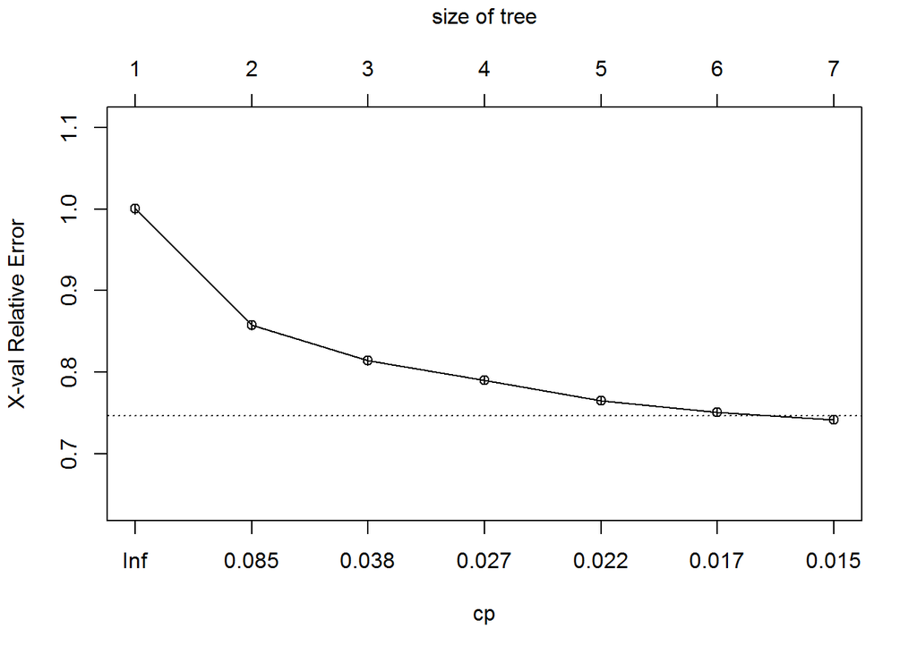

```r
plotcp(desiciontree2)
```

# Decision Tree with diabetesMed to be predicted (visual)

```
## [1] NA
```

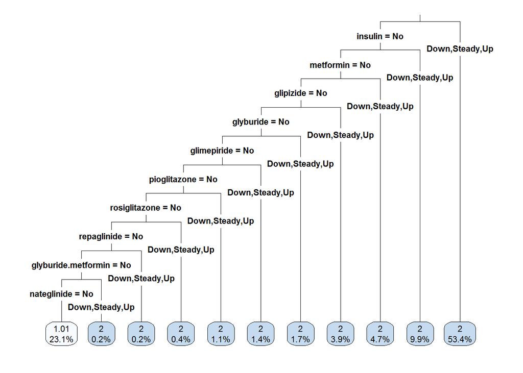

```
## [1] NA
```

```
## [1] NA
```

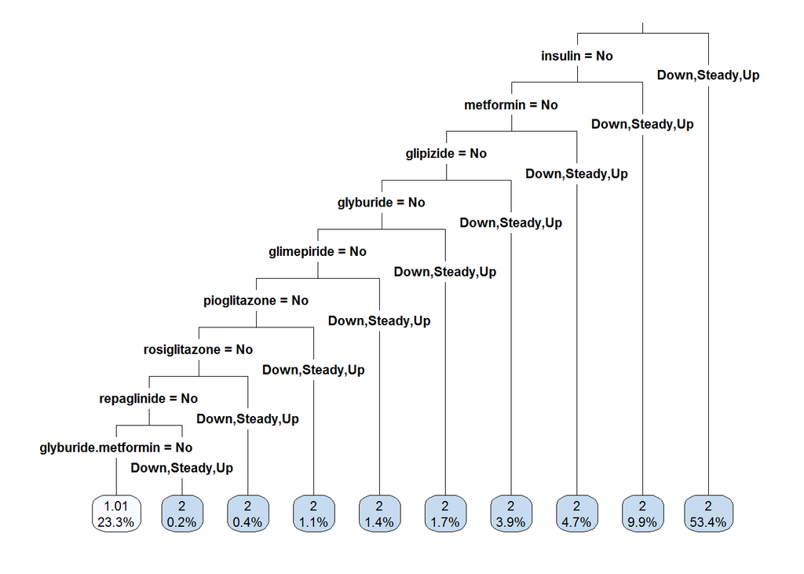

```
## [1] NA
```

```
## [1] NA
```

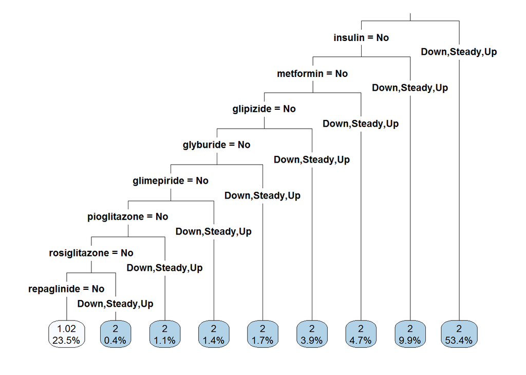

```
## [1] NA
```

```r
require(rpart.plot)
for (i in 1:3){
  set.seed(124)
  desiciontree1 <- rpart(diabetesMed~., data=traindiabet, control=rpart.control(minbucket = 2+i,cp=0.005*i),method = "anova")

  rpart.plot(desiciontree1,type = 3,digits = 3,fallen.leaves = TRUE)
  #Predictions
  pred1train<-predict(desiciontree1,traindiabet)
  #Mean Absolute Error for train data

  MeanAbsError<-function(actual,predicted){mean(abs(actual - predicted))
  }
  pred1test<-predict(desiciontree1,testdiabet)

  #mean absolute error for train data is found as
  print(MeanAbsError(traindiabet$diabetesMed,pred1train))
  #mean absolute error for test data is found as
  print(MeanAbsError(testdiabet$diabetesMed,pred1test))
}
```

```r
print(desiciontree1)
```

```
## n= 76324
##
## node), split, n, deviance, yval
##       * denotes terminal node
##
##   1) root 76324 13515.6200 1.770033
##     2) insulin=No 35565  8889.7560 1.506481
##       4) metformin=No 28047  6567.8410 1.374193
##         8) glipizide=No 24426  4939.5090 1.281421
##          16) glyburide=No 21419  3168.8490 1.180541
##            32) glimepiride=No 20141  2256.2000 1.128544
##              64) pioglitazone=No 19040  1371.7110 1.078151
##               128) rosiglitazone=No 18225   648.1479 1.036927
##                 256) repaglinide=No 17936   375.7788 1.021409 *
##                 257) repaglinide=Down,Steady,Up 289     0.0000 2.000000 *
##               129) rosiglitazone=Down,Steady,Up 815     0.0000 2.000000 *
##              65) pioglitazone=Down,Steady,Up 1101     0.0000 2.000000 *
##            33) glimepiride=Down,Steady,Up 1278     0.0000 2.000000 *
##          17) glyburide=Down,Steady,Up 3007     0.0000 2.000000 *
##         9) glipizide=Down,Steady,Up 3621     0.0000 2.000000 *
##       5) metformin=Down,Steady,Up 7518     0.0000 2.000000 *
##     3) insulin=Down,Steady,Up 40759     0.0000 2.000000 *
```

```r
print("cp values for error rates")
```

```
## [1] "cp values for error rates"
```

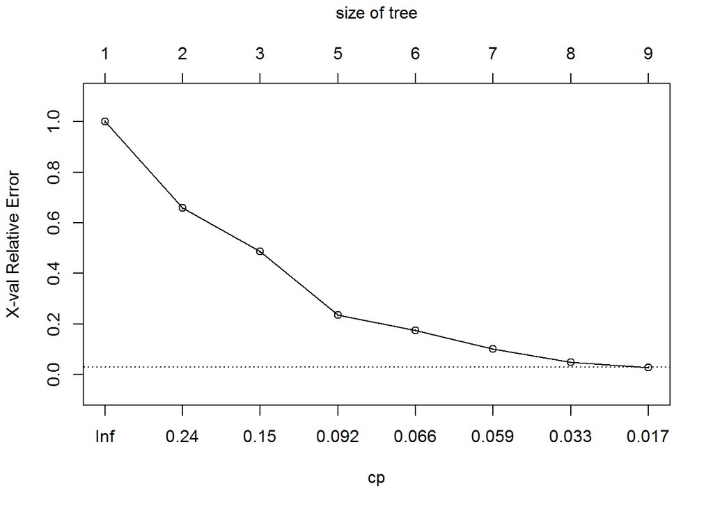

```r
plotcp(desiciontree1)
```

Stochastic Gradient Boosting for 2nd Dataset

```r
#Stochastic Gradient Boosting
```

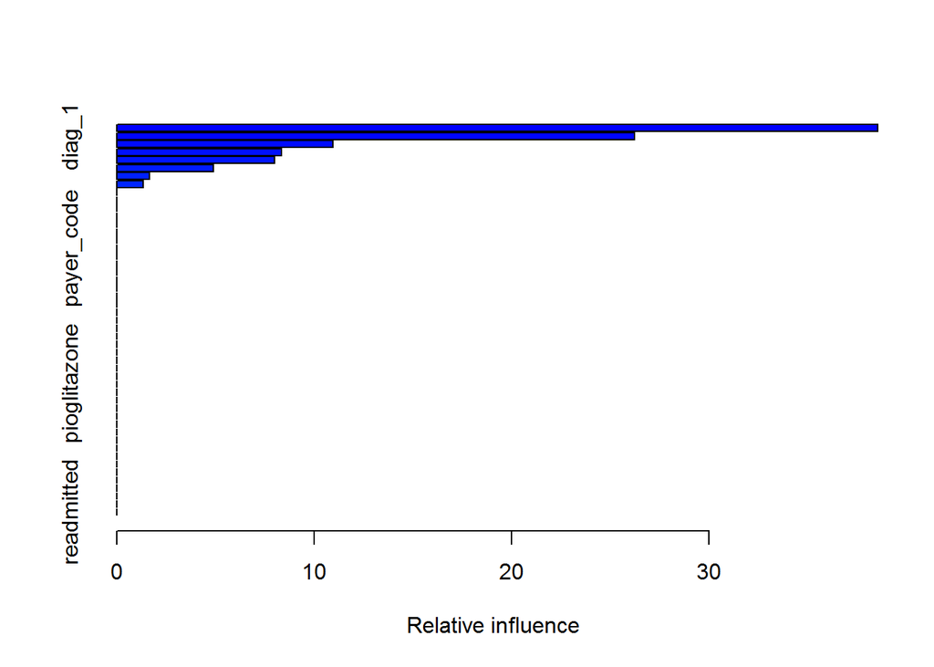

```
##                                               var   rel.inf
## num_medications                   num_medications 38.550075
## diag_1                                     diag_1 26.224216
## num_lab_procedures             num_lab_procedures 10.966854
## diag_3                                     diag_3  8.345960
## discharge_disposition_id discharge_disposition_id  8.005964
## diag_2                                     diag_2  4.909688
## num_procedures                     num_procedures  1.664007
## encounter_id                         encounter_id  1.333236
## patient_nbr                           patient_nbr  0.000000
## race                                         race  0.000000
## gender                                     gender  0.000000
## age                                           age  0.000000
## weight                                     weight  0.000000
## admission_type_id               admission_type_id  0.000000
## admission_source_id           admission_source_id  0.000000
## payer_code                             payer_code  0.000000
## medical_specialty               medical_specialty  0.000000
## number_outpatient               number_outpatient  0.000000
## number_emergency                 number_emergency  0.000000
## number_inpatient                 number_inpatient  0.000000
## number_diagnoses                 number_diagnoses  0.000000
## max_glu_serum                       max_glu_serum  0.000000
## A1Cresult                               A1Cresult  0.000000
## metformin                               metformin  0.000000
## repaglinide                           repaglinide  0.000000
## nateglinide                           nateglinide  0.000000
## chlorpropamide                     chlorpropamide  0.000000
## glimepiride                           glimepiride  0.000000
## acetohexamide                       acetohexamide  0.000000
## glipizide                               glipizide  0.000000
## glyburide                               glyburide  0.000000
## tolbutamide                           tolbutamide  0.000000
## pioglitazone                         pioglitazone  0.000000
## rosiglitazone                       rosiglitazone  0.000000
## acarbose                                 acarbose  0.000000
## miglitol                                 miglitol  0.000000
## troglitazone                         troglitazone  0.000000
## tolazamide                             tolazamide  0.000000
## examide                                   examide  0.000000
## citoglipton                           citoglipton  0.000000
## insulin                                   insulin  0.000000
## glyburide.metformin           glyburide.metformin  0.000000
## glipizide.metformin           glipizide.metformin  0.000000
## glimepiride.pioglitazone glimepiride.pioglitazone  0.000000
## metformin.rosiglitazone   metformin.rosiglitazone  0.000000
## metformin.pioglitazone     metformin.pioglitazone  0.000000
## change                                     change  0.000000
## diabetesMed                           diabetesMed  0.000000
## readmitted                             readmitted  0.000000
```

```r
library(caret)
require(gbm)

set.seed(124)

boosting1<-gbm(time_in_hospital~.,data = traindiabet,distribution="gaussian",cv.folds = 3)
summary(boosting1)
```

```r
preddata1gbm<-as.data.frame(predict(boosting1,n.trees = 100))
resultgbm<-cbind(traindiabet$time_in_hospital, preddata1gbm)
```

```r
errortrain=sum((resultgbm[,2] - mean(resultgbm[,2]))^2) / sum((resultgbm[,1] - mean(resultgbm[,1]))^2)
#coefficient of determination is found as for train data
print(errortrain)
```

```
## [1] 0.2907718
```

```r
preddata1gbm<-as.data.frame(predict(boosting1,testdiabet, n.trees = 100))
resultgbm<-cbind(testdiabet$time_in_hospital, preddata1gbm)
```

```r
errortest=sum((resultgbm[,2] - mean(resultgbm[,2]))^2) / sum((resultgbm[,1] - mean(resultgbm[,1]))^2)
#coefficient of determination is found as for test data
print(errortest)
```

```
## [1] 0.2789611
```

Support Vector Machines for 2nd Datset

```r
# Support Vector Machines

library(e1071)
set.seed(124)
#the original train data had 25442 observations with 50 variables which required a very long run time in r for support vector machine code
#Therefore a short version of train data is used for this svm method for time concerns. This short version contains 200 observations with 54 variables.
#Also the variables that stayed constant during these 200 observations are eliminated for svm function to work.
Shortoftraindiabet <- read.csv(file="C:/Users/Gizem/Desktop/hw4gz/shortof_diabetic_data.csv", header=TRUE, sep=",")


shortfittedsvm<-svm(time_in_hospital~.,data = Shortoftraindiabet,kernel="radial")
print(shortfittedsvm)
```

```
##
## Call:
## svm(formula = time_in_hospital ~ ., data = Shortoftraindiabet,
##     kernel = "radial")
##
##
## Parameters:
##    SVM-Type:  eps-regression
##  SVM-Kernel:  radial
##        cost:  1
##       gamma:  0.007407407
##     epsilon:  0.1
##
##
## Number of Support Vectors:  179
```

```r
#with the same variables;
# 75% of the sample size
short_smp_size <- floor(0.75 * nrow(Shortoftraindiabet))

# set the seed to make your partition reproducible
set.seed(124)
train_ind <- sample(seq_len(nrow(Shortoftraindiabet)), size = short_smp_size)

short_traindiabet <- Shortoftraindiabet[train_ind, ]
short_testdiabet <- Shortoftraindiabet[-train_ind, ]
```

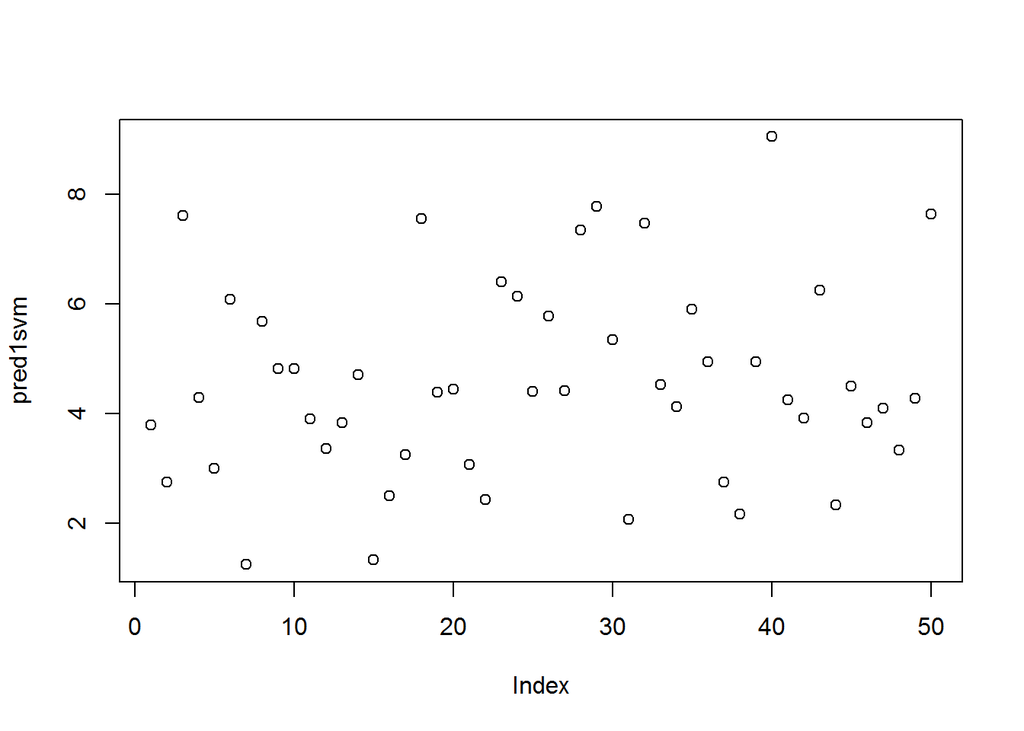

```r
pred1svm<-predict(shortfittedsvm,short_testdiabet)
plot(pred1svm)
```

```r
resultsvm<-cbind(short_testdiabet$time_in_hospital, data.frame(pred1svm))
error1svm=sum((resultsvm[,2] - mean(resultsvm[,2]))^2) / sum((resultsvm[,1] - mean(resultsvm[,1]))^2)
#"coefficient of determination is found as
print(error1svm)
```

```
## [1] 0.273013
```

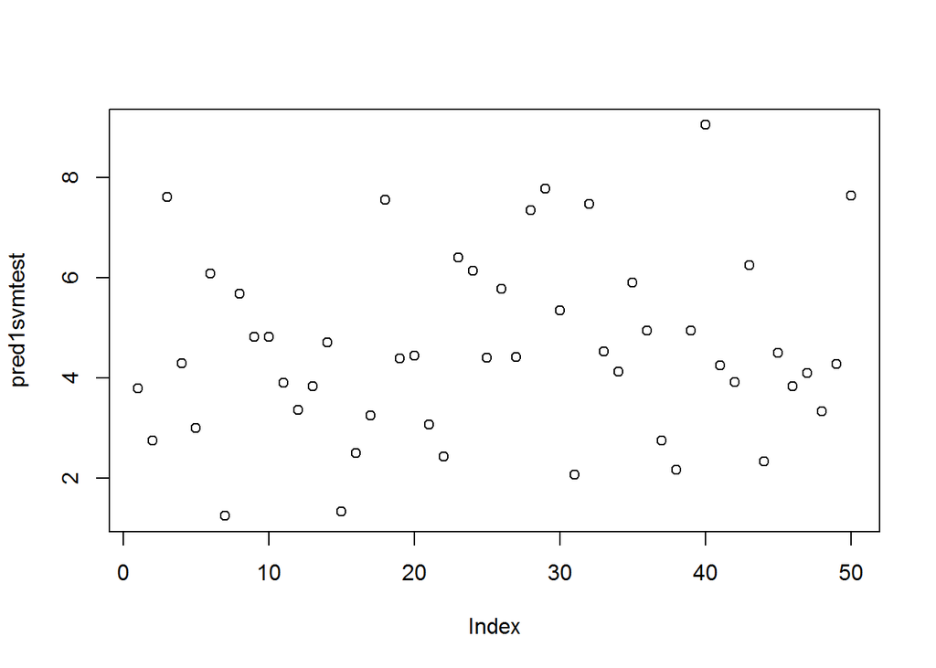

```r
pred1svmtest<-predict(shortfittedsvm,short_testdiabet)
plot(pred1svmtest)
```

```r
result1svmtest<-cbind(short_testdiabet$time_in_hospital, data.frame(pred1svmtest))
error1scmtest=sum((result1svmtest[,2] - mean(result1svmtest[,2]))^2) / sum((result1svmtest[,1] - mean(result1svmtest[,1]))^2)
#coefficient of determination can be found as
print(error1scmtest)
```

```
## [1] 0.273013
```

3rd Dataset

In the third data set, there are more than 20 features. The dataset is about students academics performance. This is a multiclass problem. The target integer can be selected from the dataset. It is metadata, there are only features there is no specific target. The target is chosen as 21st column, the last feature.

Dataset 3 is prepared.There was no test data, therefore it is created by using the coding below.

```r
#3
studentdata<- read.csv(file="C:/Users/Gizem/Desktop/hw4gz/data3b.csv", header=FALSE, sep=",")

## 75% of the sample size
smp_sizestud <- floor(0.75 * nrow(studentdata))

## set the seed to make your partition reproducible
set.seed(123)
train_indstud <- sample(seq_len(nrow(studentdata)), size = smp_sizestud)

trainstud <- studentdata[train_indstud, ]
teststud <- studentdata[-train_indstud, ]
```

Decision Tree for 3rd Data

```
## [1] NA
```

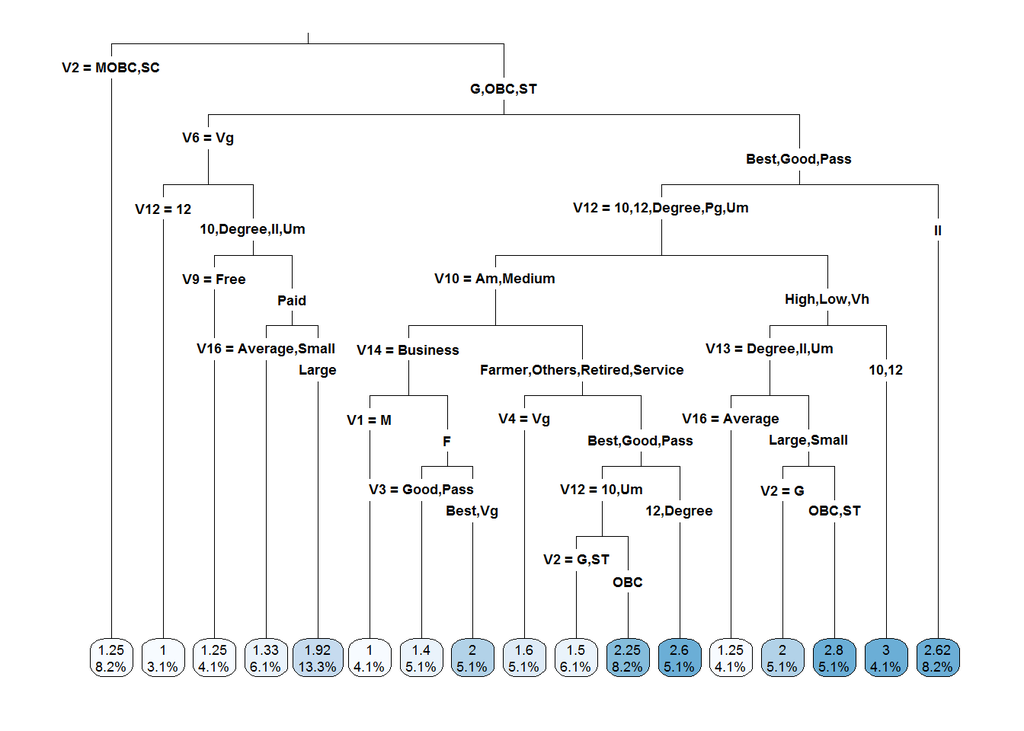

```
## [1] NA
```

```
## [1] NA
```

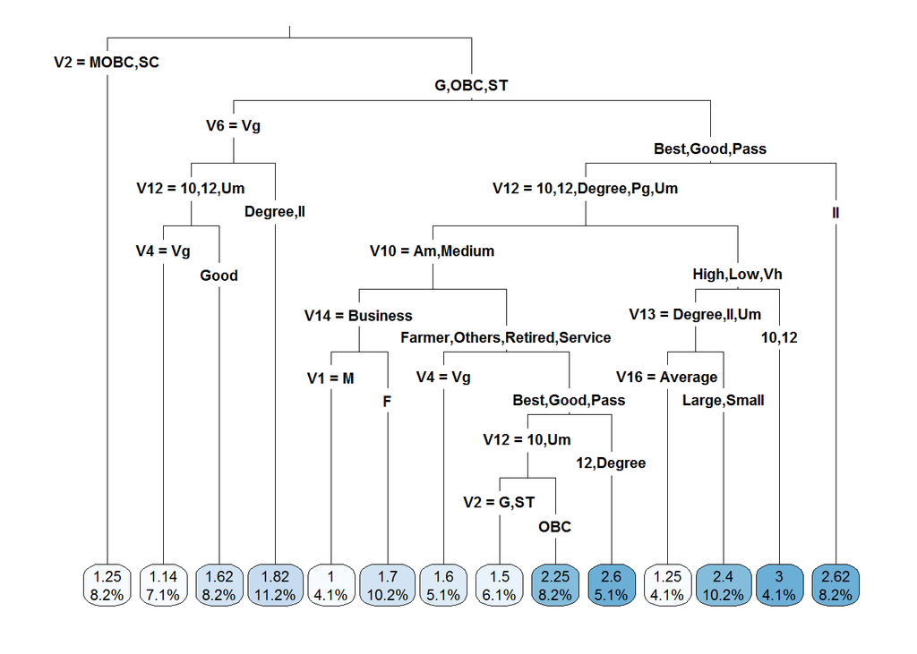

```
## [1] NA
```

```
## [1] NA
```

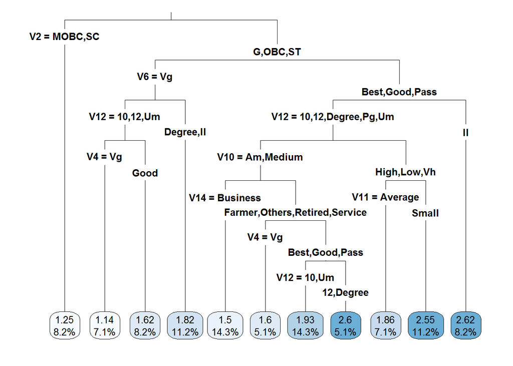

```
## [1] NA
```

```r
# Decision Tree
require(rpart.plot)
for (i in 1:3){
  set.seed(124)
  desiciontree1 <- rpart(V21 ~ V1 + V2 + V3 + V4 + V5 + V6 + V7 + V8 + V9 + V10 + V11 + V12 + V13+ V14 + V15 + V16 + V17 + V18 + V19 + V20 , data=trainstud, control=rpart.control(minbucket = 2+i,cp=0.005*i),method = "anova")

  rpart.plot(desiciontree1,type = 3,digits = 3,fallen.leaves = TRUE)
  #Predictions
 pred1train<-predict(desiciontree1,trainstud)
  #Mean Absolute Error for train data

  MeanAbsError<-function(actual,predicted){mean(abs(actual - predicted))
  }
  pred1test<-predict(desiciontree1,teststud)

  #mean absolute error for train data is found as
  print(MeanAbsError(trainstud$V21,pred1train))
  #mean absolute error for test data is found as
  print(MeanAbsError(teststud$V21,pred1test))
}
```

```r
print(desiciontree1)
```

```
## n= 98
##
## node), split, n, deviance, yval
##       * denotes terminal node
##
##   1) root 98 52.0000000 1.857143
##     2) V2=MOBC,SC 8  1.5000000 1.250000 *
##     3) V2=G,OBC,ST 90 47.2888900 1.911111
##       6) V6=Vg 26  6.3461540 1.576923
##        12) V12=10,12,Um 15  3.6000000 1.400000
##          24) V4=Vg 7  0.8571429 1.142857 *
##          25) V4=Good 8  1.8750000 1.625000 *
##        13) V12=Degree,Il 11  1.6363640 1.818182 *
##       7) V6=Best,Good,Pass 64 36.8593800 2.046875
##        14) V12=10,12,Degree,Pg,Um 56 31.9285700 1.964286
##          28) V10=Am,Medium 38 15.7105300 1.815789
##            56) V14=Business 14  3.5000000 1.500000 *
##            57) V14=Farmer,Others,Retired,Service 24 10.0000000 2.000000
##             114) V4=Vg 5  1.2000000 1.600000 *
##             115) V4=Best,Good,Pass 19  7.7894740 2.105263
##               230) V12=10,Um 14  4.9285710 1.928571 *
##               231) V12=12,Degree 5  1.2000000 2.600000 *
##          29) V10=High,Low,Vh 18 13.6111100 2.277778
##            58) V11=Average 7  4.8571430 1.857143 *
##            59) V11=Small 11  6.7272730 2.545455 *
##        15) V12=Il 8  1.8750000 2.625000 *
```